# Analýza esportových dat

Michal Lauer

Bakalářská práce

# Úvod

Tento report se zabývá deskriptivní a inferenční analýzou dat. Dataset, který se dá získat na portálu [kaggle.com](https://www.kaggle.com/mateusdmachado/csgo-professional-matches), obsahuje 4 csv soubory

- *players.csv* -> obsahuje statistiky hráčů v zápasech. Dataset je použit pro **deskriptivní analýzu**
- *economy.csv* -> zde se nachází stav financí každého teamu v jednotlivém kole každého zápasu. Toto lze využít pro **inferenční analýzu**
- *picks.csv* -> v tomto souboru jsou vybrané mapy každého teamu v jejich zápasech. Tento soubor lze použít k **inferenční analýze** map, které si team nejspíše vybere proti oponentu
- *results.csv* -> díky tomuto souboru, který obsahuje výsledky zápasu, můžeme simulovat utkání jednotlivých teamů a určit, který team má větší šanci vyhrát. Toto je část **inferenční analýzy**

Každý soubor má vlastní sekci, která se skládá z několika částí

1. *porozumnění datasetu*
2. *nahrání, očištění a transformace dat*
3. *daná analýza*
4. *závěr*

# Statistiky hráčů

Díky souboru *players.csv* můžeme získat statistiky hráčů. Ty lze dále použít k popisu hráču, statistik dle různých kategorií, porovnání hráčů či nalezení nejlepších/nejhorších jedinců.

## Porozumnění datasetu

Dataset obsahuje záznamy o zápasech a hráčích. Každý záznam se rovná právě jednomu hráči. Zápasy můžeme spojit díky proměnné *match_id*. Každý hráč je dále identifikován svým id *(player_id)* a jménem *(player_name)*. Dále se nám hodí team, za který hráč hraje *(team)*, oponent v daném zápase *(opponent)*, jménu turnaje *(event_name)* a země, ze které daný hráč je *(country)*. O zápase známejeho typ *(best_of)* a názvy map *(map_1, map_2, map_3)*. Jednotlivé statistiky hráče obsahují počet zabití v celém zápase *(kills)*, počet asistencí v zápase *(assists)*, počet smrtí v zápase *(deaths)* a počet tzn. headshotů v zápase - usmrcení nepřátelského hráče do hlavy *(hs)*. Pokud zápas obsahoval více map, jsou dle toho statistiky dále rozděleny.

## Nahrání dat

Data narhajeme, vybere pouze sloupce, které se nám k analýze hodí a nastavíme jim správné datové typy.

```r
library(tidyverse)
players <- read_csv("data/players.csv",
                    col_select = c("date", "player_name", "team", "opponent", "country",
                                   "player_id", "match_id",
                                   "event_name", "best_of", "map_1", "map_2", "map_3",
                                   "kills", "assists", "deaths", "hs",
                                   "m1_kills", "m1_assists", "m1_deaths","m1_hs",
                                   "m2_kills", "m2_assists", "m2_deaths","m2_hs",
                                   "m3_kills", "m3_assists", "m3_deaths","m3_hs"),
                    col_types = list(
                      date = col_date(),
                      player_name = col_factor(),
                      team = col_factor(),
                      opponent = col_factor(),
                      country = col_factor(),
                      player_id = col_factor(),
                      match_id = col_factor(),
                      event_name = col_factor(),
                      best_of = col_factor(levels = c("1","2","3","5"),
                                           ordered = T),
                      map_1 = col_factor(),
                      map_2 = col_factor(),
                      map_3 = col_factor()
                    )
) %>%
  mutate(
    across(.cols = everything(), .fns = na_if, y = "")
    )

attr(players, "spec") <- NULL

players %>%
  sample_n(10) %>%
  str
```

```
## tibble [10 x 28] (S3: tbl_df/tbl/data.frame)
##  $ date       : Date[1:10], format: "2017-11-25" "2018-11-18" ...
##  $ player_name: Factor w/ 11992 levels "Brehze","CeRq",..: 4553 1043 40 2926 4923 52 3767 1043 1355 714
##  $ team       : Factor w/ 4154 levels "Evil Geniuses",..: 159 1407 227 33 3213 12 441 7 324 320
##  $ opponent   : Factor w/ 4154 levels "Liquid","Evil Geniuses",..: 1263 189 471 2717 716 3005 620 3310 584 2038
##  $ country    : Factor w/ 112 levels "United States",..: 14 17 9 12 3 22 24 17 51 22
##  $ player_id  : Factor w/ 12295 levels "9136","11219",..: 4597 1051 40 2946 4973 52 3801 1051 1366 720
##  $ match_id   : Factor w/ 38375 levels "2339385","2339391",..: 20769 9900 19610 32806 35836 35443 6243 37446 2558 23246
##  $ event_name : Factor w/ 3158 levels "IEM Katowice 2020",..: 1840 984 1682 2596 2966 2930 572 3100 96 2004
##  $ best_of    : Ord.factor w/ 4 levels "1"<"2"<"3"<"5": 1 3 3 3 3 2 1 3 3 3
##  $ map_1      : Factor w/ 10 levels "Overpass","Mirage",..: 9 3 1 5 2 2 4 3 2 5
##  $ map_2      : Factor w/ 11 levels "Nuke","Inferno",..: NA 6 9 9 9 9 NA 11 2 11
##  $ map_3      : Factor w/ 10 levels "Inferno","Nuke",..: NA NA NA NA 6 NA NA NA NA NA
##  $ kills      : num [1:10] 15 31 31 36 56 37 29 41 46 28
##  $ assists    : num [1:10] 2 13 11 12 6 6 9 7 12 15
##  $ deaths     : num [1:10] 17 42 28 44 57 20 20 27 41 31
##  $ hs         : num [1:10] 6 16 4 19 21 20 12 18 16 10
##  $ m1_kills   : num [1:10] 15 15 19 11 19 19 29 24 20 16
##  $ m1_assists : num [1:10] 2 9 3 6 1 2 9 2 6 5
##  $ m1_deaths  : num [1:10] 17 21 9 17 20 7 20 15 16 14
##  $ m1_hs      : num [1:10] 6 10 3 3 10 11 12 11 7 4
##  $ m2_kills   : num [1:10] NA 16 12 25 14 18 NA 17 26 12
##  $ m2_assists : num [1:10] NA 3 8 6 4 4 NA 5 6 10
##  $ m2_deaths  : num [1:10] NA 21 19 27 20 13 NA 12 25 17
##  $ m2_hs      : num [1:10] NA 6 1 16 6 9 NA 7 9 6
##  $ m3_kills   : num [1:10] NA NA NA NA 23 NA NA NA NA NA
##  $ m3_assists : num [1:10] NA NA NA NA 1 NA NA NA NA NA
##  $ m3_deaths  : num [1:10] NA NA NA NA 17 NA NA NA NA NA
##  $ m3_hs      : num [1:10] NA NA NA NA 5 NA NA NA NA NA
```

## Očištění dat

Data je načase očistit. Prve zjistíme, kde se nachází NA hodnoty.

```r
count_na(players)
```

| column_name | count_of_NAs | percent_ratio |
| --- | --- | --- |
| player_name | 1 | 2.608807e-04 |
| map_2 | 186794 | 4.873095e+01 |
| map_3 | 314639 | 8.208324e+01 |
| m2_kills | 187127 | 4.881782e+01 |
| m2_assists | 187127 | 4.881782e+01 |
| m2_deaths | 187127 | 4.881782e+01 |
| m2_hs | 187127 | 4.881782e+01 |
| m3_kills | 314801 | 8.212550e+01 |
| m3_assists | 314801 | 8.212550e+01 |
| m3_deaths | 314801 | 8.212550e+01 |

[output cut: 1 more lines]

NA v prvním sloupci jsou problém. Pokud nemáme jméno hráče, data nám moc užitečná nebudou - záznam proto smažeme. Zbývající proměnné problém nejsou. Ne každý zápas měl druhou či třetí mapu. Pokud třetí mapu neměl, data z ní nebudou existovat.

```r
players <- players  %>%
  filter(!is.na(player_name))
```

## Transformace dat

Data jsou již očištěna a zkontrolována. Nyní přídamě několik proměnných. Začneme rokmen a měsícem daného zápasu. Tvorba je velmi jednoduchá, jelikož sloupce jdou lehce odvodit z proměnné *date*. Dále přidáme kontinent, který reprezentuje původ hráče. Tohoto jde lehce docílit pomocí package *countrycode*. V případě, že je kontinent *NA*, záznam odstraníme. Jedná se pouze o 15 záznamu, což analýzu nijak zvláštně neovlivní.

```r
library(countrycode)
players <- players %>%
  filter(country != "Other") %>%
  mutate(year = format(date, "%Y"),
         month = format(date, "%B"),
         player_name = fct_relevel(player_name, sort),
         continent = countrycode(country, "country.name", "continent")
         )

players %>%
  select(date, player_name, month, year, continent) %>%
  sample_n(10)
```

| date | player_name | month | year | continent |
| --- | --- | --- | --- | --- |
| 2018-11-25 | KneeLz | listopad | 2018 | Europe |
| 2018-08-18 | Papichulo | srpen | 2018 | Asia |
| 2015-12-03 | oskarish | prosinec | 2015 | Europe |
| 2018-09-07 | cleMeNz0 | září | 2018 | Europe |
| 2016-03-25 | inVert | březen | 2016 | Americas |
| 2018-10-06 | Xyp9x | říjen | 2018 | Europe |
| 2018-06-06 | Toy | červen | 2018 | Americas |
| 2020-02-15 | vhz | únor | 2020 | Americas |
| 2019-08-11 | Welshy | srpen | 2019 | Americas |
| 2016-07-06 | f0rest | červenec | 2016 | Europe |

## Deskriptivní popis dat

### Statistiky podle čísla mapy

Prve se podíváme porovnáme čtyři sledované statistiky podle čísla mapy

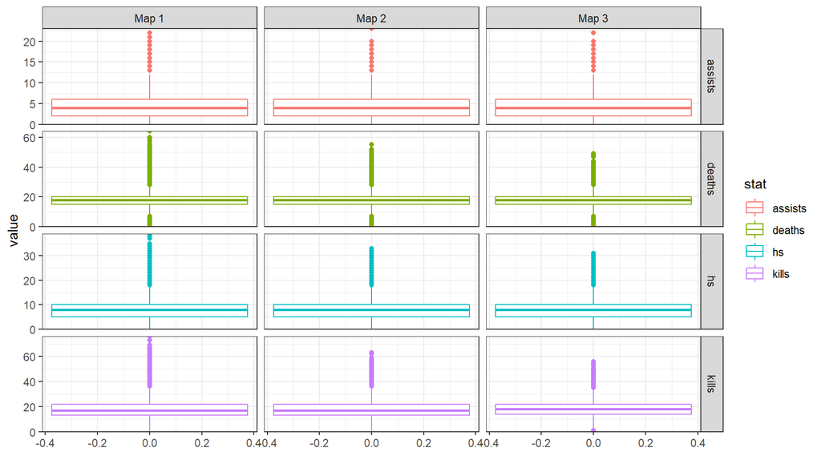

```r
players.stats_per_map_num <- players %>%
  select(m1_kills:m3_hs) %>%
  pivot_longer(everything(), names_to = "stat", values_to = "value") %>%
  mutate(map = paste0("Map ", substring(stat, 2, 2)),
         stat = substring(stat, 4, length(stat))) %>%
  filter(!is.na(value))

ggplot(players.stats_per_map_num, aes(y = value, color = stat)) +
  geom_boxplot() +
  facet_grid(rows = vars(stat), cols = vars(map),
             scales = "free_y") +
  theme_bw() +
  scale_y_continuous(expand = c(0,0))
```

Vidíme, že se zde nachází mnoho extrémních hodnot. Toto se může stát z více důvodů. Mapa můžeš jít např. do prodloužení *(počet kol je prakticky neomezen)*. Může se také stát, že jeden hráč je o mnoho řad lepší, než ostatní hráčí. Podívejme se nyní na box ploty bez těchto extrémních hodnot

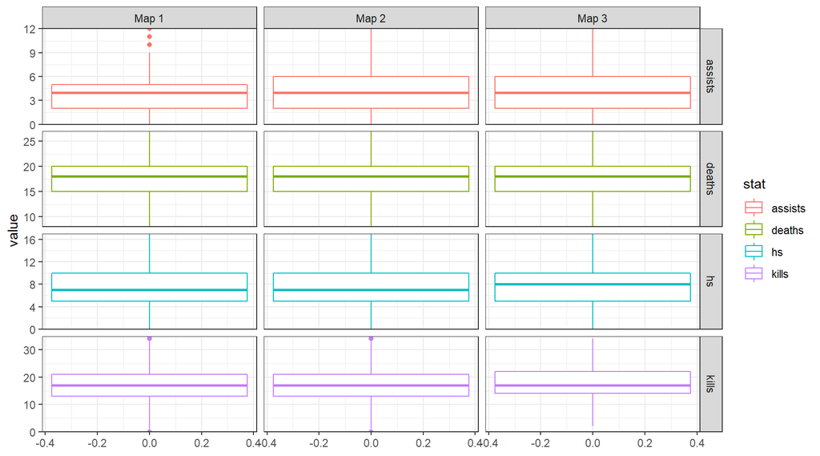

```r
players.stats_per_map_num_outlier_lims <- players.stats_per_map_num %>%
  group_by(map, stat) %>%
  summarise(IQR = IQR(value, type = 2),
            upper_limit = quantile(value, 0.75) + IQR * 1.5,
            lower_limit = quantile(value, 0.25) - IQR * 1.5) %>%
  select(!IQR)

players.stats_per_map_num_no_outliers <- players.stats_per_map_num %>%
  left_join(players.stats_per_map_num_outlier_lims, by = c("map", "stat")) %>%
  filter(value <= upper_limit, value >= lower_limit)

ggplot(players.stats_per_map_num_no_outliers, aes(y = value, color = stat)) +
  geom_boxplot() +
  facet_grid(rows = vars(stat), cols = vars(map),
             scales = "free_y") +
  theme_bw() +
  scale_y_continuous(expand = c(0,0))
```

Nyní můžeme vidět, že medián a mezikvartilové rozpětí všech statistik je velmi podobné. Největší rozdíl se nachází u asistencí na první mapě. Podívejme se ještě na normalizovanou distribuci dat

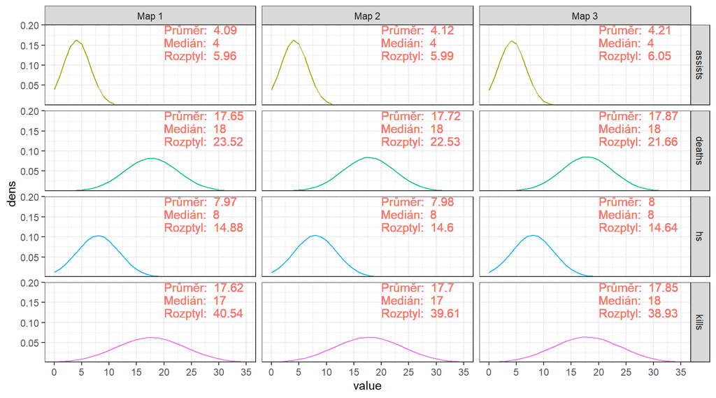

```r
players.hist <- players.stats_per_map_num %>%
  group_by(map, stat) %>%
  mutate(mean = mean(value),
         median = median(value),
         sd = sd(value)) %>%
  unique() %>%
  mutate(dens = dnorm(value, mean, sd)) %>%
  filter(dens >= 0.001)

ggplot(players.hist, aes(x = value, y = dens, color = stat)) +
  geom_line() +
  geom_text(aes(x = 20, y = 0.2,
                label = paste("Průměr: ", round(mean, 2)),
                vjust = "top", hjust = "left",
                color = "#fff")) +
  geom_text(aes(x = 20, y = 0.2,
                label = paste("Medián: ", round(median, 2)),
                vjust = 2.4, hjust = "left",
                color = "#fff")) +
  geom_text(aes(x = 20, y = 0.2,
                label = paste("Rozptyl: ", round(sd^2, 2)),
                vjust = 3.8, hjust = "left",
                color = "#fff")) +
  facet_grid(rows = vars(stat), cols = vars(map),
             scales = "free") +
  scale_y_continuous(expand = c(0,0)) +
  scale_x_continuous(breaks = seq(0, 35, by = 5)) +
  theme_bw() +
  theme(legend.position = "none")
```

Z grafů si můžeme všimnout, že mapy na průměrný výkon hráčů nemají veliký vliv. Malý rozptyl značí, že se hodnoty pohybují blízko mediánu *(proměnná assists*). Pokud je rozptyl větší, hodnoty jsou více rozprostřené *(nejvíce u proměnné kills)*.

### Statistiky podle jména mapy

Jelikož proměnná *kills* má největší rozptyl, podíváme se ještě na její rozbor dle různých map. Pro tuto analýzu odstraníme mapu s názvem “Default” - jedná se o specální výběr, pod kterým se skrývá jiná mapa, která bohužel v datasetu chybí.

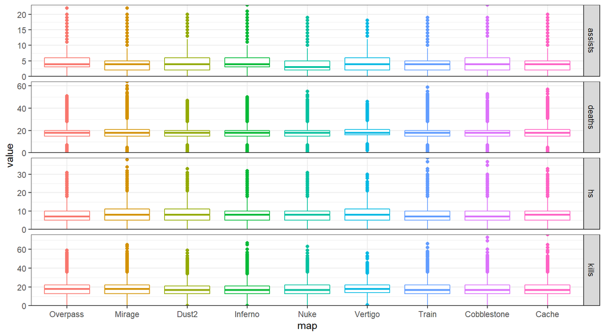

```r
get_map_stats <- \(data, i) {
  players %>%
    select(matches(as.character(i))) %>%
    rename(map = 1, kills = 2, assists = 3, deaths = 4, hs = 5) %>%
    filter(map != "Default", !is.na(map)) %>%
    pivot_longer(!map, names_to = "stat", values_to = "value") %>%
    filter(!is.na(value))
}

players.stats_per_map_name <- get_map_stats(players, 1) %>%
  rbind(get_map_stats(players, 2)) %>%
   rbind(get_map_stats(players, 3))


ggplot(players.stats_per_map_name, aes(x = map, y = value,
                                       color = map)) +
  geom_boxplot() +
  facet_grid(rows = vars(stat),
             scales = "free") +
  scale_y_continuous(expand = c(0,0)) +
  theme_bw() +
  theme(legend.position = "none")
```

Vidíme, že v datech máme mnoho outliers. Pro lepší zobrazení bude dobré se podívat na data, kde tyto outliers vyloučíme.

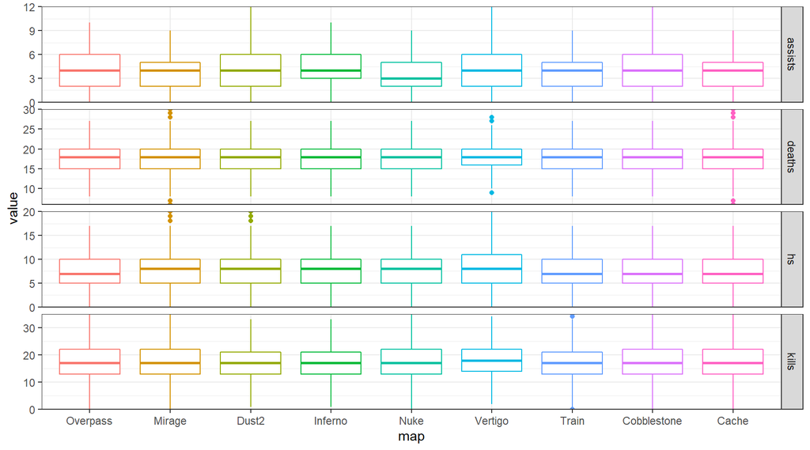

```r
players.stats_per_map_outlier_lims <- players.stats_per_map_name %>%
  group_by(map, stat) %>%
  summarise(IQR = IQR(value, type = 2),
            upper_limit = quantile(value, 0.75) + IQR * 1.5,
            lower_limit = quantile(value, 0.25) - IQR * 1.5) %>%
  select(!IQR)

players.stats_per_map_name_no_out <- players.stats_per_map_name %>%
  left_join(players.stats_per_map_outlier_lims, by = c("map", "stat")) %>%
  filter(value <= upper_limit, value >= lower_limit) %>%
  select(!upper_limit)

ggplot(players.stats_per_map_name_no_out, aes(x = map, y = value,
                                       color = map)) +
  geom_boxplot() +
  facet_grid(rows = vars(stat),
             scales = "free") +
  scale_y_continuous(expand = c(0,0)) +
  theme_bw() +
  theme(legend.position = "none")
```

### Celkové statistiky

Můžeme znovu vidět, že statistiky se mezi mapami nijak výrazně neliší. Nakonec se podíváme na distribuci celkovou distribuci statistik.

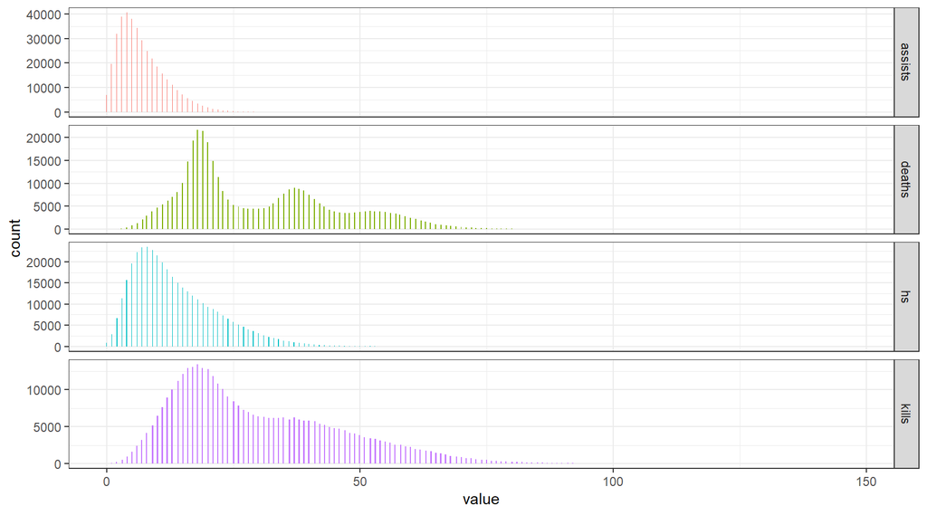

```r
players.stats <- players %>%
  select(player_id | c(kills:hs)) %>%
  pivot_longer(!player_id, names_to = "stat", values_to = "value") %>%
  select(!player_id)


ggplot(players.stats, aes(x = value)) +
  facet_grid(rows = vars(stat), scales = "free") +
  geom_histogram(aes(fill = stat),
                 binwidth = function(x) { (max(x) - min(x)) / sqrt(length(x)) } ) +
  theme_bw() +
  theme(legend.position = "none")
```